# MANOVA and A Cool Thing Called PERMANOVA

Nathaniel

2019-06-19

## MANOVA

MANOVA stands for Multivariate (or Multiple) Analysis of Variance, and it’s just what it sounds like. You have multiple *response* variables, and you want to test whether any of them differ across levels of your explanatory variable(s) (i.e., your groups). The null hypothesis here is that the means of each response variable are equal at every level of the explanatory variable(s); the alternative is that at least one response variable differs.

It’s very similar to Univariate ANOVA, except we generalize it into $p$ dimensions, where $p$ is the number of response variables. Let’s build some intuition!

Say you want to know whether horsepower or gas mileage differ based on whether a car has a manual or automatic transmission. We will use the built-in dataset `mtcars` to make following along at home easier to do. Note that this dataset comes from 1974 Motor Trend magazine and has several car performance variables for each of 32 different makes/models of car. It’s super easy to run a MANOVA, but it takes a bit of effort to understand what is going on. Let’s run it first, and then dissect what’s actually happening, erm, under the hood.

```r
summary(manova(cbind(hp,mpg)~am,data=mtcars))
```

```
##           Df  Pillai approx F num Df den Df    Pr(>F)
## am         1 0.48417    13.61      2     29 6.781e-05 ***
## Residuals 30
## ---
## Signif. codes:  0 '***' 0.001 '**' 0.01 '*' 0.05 '.' 0.1 ' ' 1
```

Notice the response variables (hp, mpg) have to be entered as $p$-column matrix (where $p$ is the number of variables): That’s what the `cbind()` is for. The short answer is yes, there is a mean difference in either horsepower or mpg for cars with automatic transmissions compared to those with manual transmissions. Which one is it? Is it both?

```r
summary(aov(hp~am,data=mtcars))
```

```
##             Df Sum Sq Mean Sq F value Pr(>F)
## am           1   8619    8619   1.886   0.18
## Residuals   30 137107    4570
```

```r
summary(aov(mpg~am,data=mtcars))
```

```
##             Df Sum Sq Mean Sq F value   Pr(>F)
## am           1  405.2   405.2   16.86 0.000285 ***
## Residuals   30  720.9    24.0
## ---
## Signif. codes:  0 '***' 0.001 '**' 0.01 '*' 0.05 '.' 0.1 ' ' 1
```

Looks like there is a difference in gas mileage between automatics and manuals, but no difference in horsepower.

## What’s going on here?

If you understand the logic of ANOVA (i.e., partitioning the total variation into a component attributable to differences *between groups* and an error component attributable to differences *within groups*), the MANOVA shouldn’t be too big of a leap: we just have to add dimension(s) for the additional response variables.

With an ANOVA, we calculate the total sum of squares (SST) by taking the distance of each subject’s response value from the mean response value, square these distances, and add them up.

With a MANOVA, we do something similar, but in two-dimensions: we calculate how far each subjects’ `response vector` is from the `mean vector`. Just imagine plotting both response variables against eachother in a coordinate plane, and then plotting the point that corresponds to the average value of each (large gray dot), like so

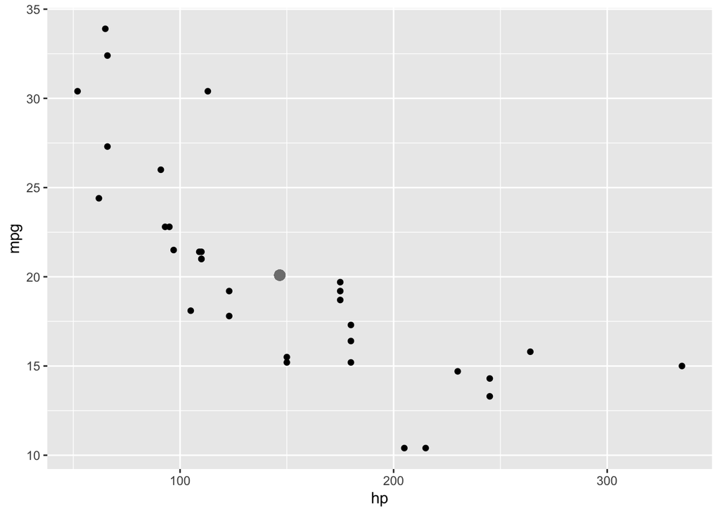

```r
library(ggplot2)
ggplot(mtcars,aes(hp,mpg))+geom_point()+geom_point(aes(x=mean(hp),y=mean(mpg)),col='gray50',size=3)
```